# Bank_Project

## Project : Bank desertion rate.

```python
import pandas as pd
import seaborn as sns
import numpy as np
import matplotlib.pyplot as plt
from sklearn.preprocessing import OrdinalEncoder, OneHotEncoder, StandardScaler
from sklearn.tree import DecisionTreeClassifier
from sklearn.svm import SVC
from sklearn.model_selection import train_test_split, GridSearchCV
from sklearn.linear_model import LogisticRegression
from sklearn.metrics import classification_report, confusion_matrix, accuracy_score, roc_curve, auc, roc_auc_score, precision_recall_curve, average_precision_score
from sklearn.ensemble import RandomForestClassifier, BaggingClassifier, VotingClassifier, StackingClassifier
```

### 1 - Descriptive Analysis

```python
df = pd.read_csv("BankChurners.csv", sep = ",", usecols=list(range(0,21)))
```

```python
df.head()
```

|  | CLIENTNUM | Attrition_Flag | Customer_Age | Gender | Dependent_count | Education_Level | Marital_Status | Income_Category | Card_Category | Months_on_book | ... | Months_Inactive_12_mon | Contacts_Count_12_mon | Credit_Limit | Total_Revolving_Bal | Avg_Open_To_Buy | Total_Amt_Chng_Q4_Q1 | Total_Trans_Amt | Total_Trans_Ct | Total_Ct_Chng_Q4_Q1 | Avg_Utilization_Ratio |
| --- | --- | --- | --- | --- | --- | --- | --- | --- | --- | --- | --- | --- | --- | --- | --- | --- | --- | --- | --- | --- | --- |
| 0 | 768805383 | Existing Customer | 45 | M | 3 | High School | Married | $60K - $80K | Blue | 39 | ... | 1 | 3 | 12691.0 | 777 | 11914.0 | 1.335 | 1144 | 42 | 1.625 | 0.061 |
| 1 | 818770008 | Existing Customer | 49 | F | 5 | Graduate | Single | Less than $40K | Blue | 44 | ... | 1 | 2 | 8256.0 | 864 | 7392.0 | 1.541 | 1291 | 33 | 3.714 | 0.105 |
| 2 | 713982108 | Existing Customer | 51 | M | 3 | Graduate | Married | $80K - $120K | Blue | 36 | ... | 1 | 0 | 3418.0 | 0 | 3418.0 | 2.594 | 1887 | 20 | 2.333 | 0.000 |
| 3 | 769911858 | Existing Customer | 40 | F | 4 | High School | Unknown | Less than $40K | Blue | 34 | ... | 4 | 1 | 3313.0 | 2517 | 796.0 | 1.405 | 1171 | 20 | 2.333 | 0.760 |
| 4 | 709106358 | Existing Customer | 40 | M | 3 | Uneducated | Married | $60K - $80K | Blue | 21 | ... | 1 | 0 | 4716.0 | 0 | 4716.0 | 2.175 | 816 | 28 | 2.500 | 0.000 |

5 rows × 21 columns

```python
df.tail()
```

|  | CLIENTNUM | Attrition_Flag | Customer_Age | Gender | Dependent_count | Education_Level | Marital_Status | Income_Category | Card_Category | Months_on_book | ... | Months_Inactive_12_mon | Contacts_Count_12_mon | Credit_Limit | Total_Revolving_Bal | Avg_Open_To_Buy | Total_Amt_Chng_Q4_Q1 | Total_Trans_Amt | Total_Trans_Ct | Total_Ct_Chng_Q4_Q1 | Avg_Utilization_Ratio |
| --- | --- | --- | --- | --- | --- | --- | --- | --- | --- | --- | --- | --- | --- | --- | --- | --- | --- | --- | --- | --- | --- |
| 10122 | 772366833 | Existing Customer | 50 | M | 2 | Graduate | Single | $40K - $60K | Blue | 40 | ... | 2 | 3 | 4003.0 | 1851 | 2152.0 | 0.703 | 15476 | 117 | 0.857 | 0.462 |
| 10123 | 710638233 | Attrited Customer | 41 | M | 2 | Unknown | Divorced | $40K - $60K | Blue | 25 | ... | 2 | 3 | 4277.0 | 2186 | 2091.0 | 0.804 | 8764 | 69 | 0.683 | 0.511 |
| 10124 | 716506083 | Attrited Customer | 44 | F | 1 | High School | Married | Less than $40K | Blue | 36 | ... | 3 | 4 | 5409.0 | 0 | 5409.0 | 0.819 | 10291 | 60 | 0.818 | 0.000 |
| 10125 | 717406983 | Attrited Customer | 30 | M | 2 | Graduate | Unknown | $40K - $60K | Blue | 36 | ... | 3 | 3 | 5281.0 | 0 | 5281.0 | 0.535 | 8395 | 62 | 0.722 | 0.000 |
| 10126 | 714337233 | Attrited Customer | 43 | F | 2 | Graduate | Married | Less than $40K | Silver | 25 | ... | 2 | 4 | 10388.0 | 1961 | 8427.0 | 0.703 | 10294 | 61 | 0.649 | 0.189 |

5 rows × 21 columns

```python
df.info()
```

```
<class 'pandas.core.frame.DataFrame'>
RangeIndex: 10127 entries, 0 to 10126
Data columns (total 21 columns):
 #   Column                    Non-Null Count  Dtype
---  ------                    --------------  -----
 0   CLIENTNUM                 10127 non-null  int64
 1   Attrition_Flag            10127 non-null  object
 2   Customer_Age              10127 non-null  int64
 3   Gender                    10127 non-null  object
 4   Dependent_count           10127 non-null  int64
 5   Education_Level           10127 non-null  object
 6   Marital_Status            10127 non-null  object
 7   Income_Category           10127 non-null  object
 8   Card_Category             10127 non-null  object
 9   Months_on_book            10127 non-null  int64
 10  Total_Relationship_Count  10127 non-null  int64
 11  Months_Inactive_12_mon    10127 non-null  int64
 12  Contacts_Count_12_mon     10127 non-null  int64
 13  Credit_Limit              10127 non-null  float64
 14  Total_Revolving_Bal       10127 non-null  int64
 15  Avg_Open_To_Buy           10127 non-null  float64
 16  Total_Amt_Chng_Q4_Q1      10127 non-null  float64
 17  Total_Trans_Amt           10127 non-null  int64
 18  Total_Trans_Ct            10127 non-null  int64
 19  Total_Ct_Chng_Q4_Q1       10127 non-null  float64
 20  Avg_Utilization_Ratio     10127 non-null  float64
dtypes: float64(5), int64(10), object(6)
memory usage: 1.6+ MB
```

```python
df.describe()
```

|  | CLIENTNUM | Customer_Age | Dependent_count | Months_on_book | Total_Relationship_Count | Months_Inactive_12_mon | Contacts_Count_12_mon | Credit_Limit | Total_Revolving_Bal | Avg_Open_To_Buy | Total_Amt_Chng_Q4_Q1 | Total_Trans_Amt | Total_Trans_Ct | Total_Ct_Chng_Q4_Q1 | Avg_Utilization_Ratio |
| --- | --- | --- | --- | --- | --- | --- | --- | --- | --- | --- | --- | --- | --- | --- | --- |
| count | 1.012700e+04 | 10127.000000 | 10127.000000 | 10127.000000 | 10127.000000 | 10127.000000 | 10127.000000 | 10127.000000 | 10127.000000 | 10127.000000 | 10127.000000 | 10127.000000 | 10127.000000 | 10127.000000 | 10127.000000 |
| mean | 7.391776e+08 | 46.325960 | 2.346203 | 35.928409 | 3.812580 | 2.341167 | 2.455317 | 8631.953698 | 1162.814061 | 7469.139637 | 0.759941 | 4404.086304 | 64.858695 | 0.712222 | 0.274894 |
| std | 3.690378e+07 | 8.016814 | 1.298908 | 7.986416 | 1.554408 | 1.010622 | 1.106225 | 9088.776650 | 814.987335 | 9090.685324 | 0.219207 | 3397.129254 | 23.472570 | 0.238086 | 0.275691 |
| min | 7.080821e+08 | 26.000000 | 0.000000 | 13.000000 | 1.000000 | 0.000000 | 0.000000 | 1438.300000 | 0.000000 | 3.000000 | 0.000000 | 510.000000 | 10.000000 | 0.000000 | 0.000000 |
| 25% | 7.130368e+08 | 41.000000 | 1.000000 | 31.000000 | 3.000000 | 2.000000 | 2.000000 | 2555.000000 | 359.000000 | 1324.500000 | 0.631000 | 2155.500000 | 45.000000 | 0.582000 | 0.023000 |
| 50% | 7.179264e+08 | 46.000000 | 2.000000 | 36.000000 | 4.000000 | 2.000000 | 2.000000 | 4549.000000 | 1276.000000 | 3474.000000 | 0.736000 | 3899.000000 | 67.000000 | 0.702000 | 0.176000 |
| 75% | 7.731435e+08 | 52.000000 | 3.000000 | 40.000000 | 5.000000 | 3.000000 | 3.000000 | 11067.500000 | 1784.000000 | 9859.000000 | 0.859000 | 4741.000000 | 81.000000 | 0.818000 | 0.503000 |
| max | 8.283431e+08 | 73.000000 | 5.000000 | 56.000000 | 6.000000 | 6.000000 | 6.000000 | 34516.000000 | 2517.000000 | 34516.000000 | 3.397000 | 18484.000000 | 139.000000 | 3.714000 | 0.999000 |

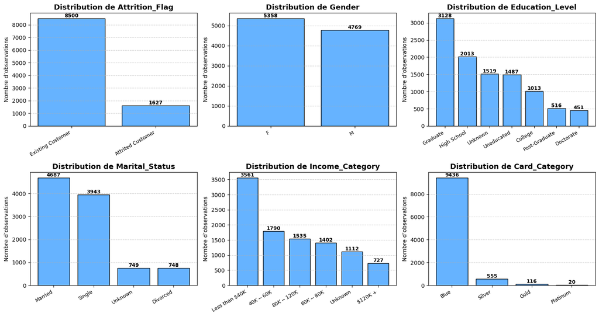

```python
cols = ['Attrition_Flag', 'Gender', 'Education_Level',
        'Marital_Status', 'Income_Category', 'Card_Category']

plt.figure(figsize=(15, 8))

for i, col in enumerate(cols, 1):
    plt.subplot(2, 3, i)

    value_counts = df[col].value_counts()
    bars = plt.bar(value_counts.index, value_counts.values,
                   color='#66b3ff', edgecolor='black')

    for bar in bars:
        height = bar.get_height()
        plt.text(bar.get_x() + bar.get_width()/2, height,
                 f'{int(height)}', ha='center', va='bottom', fontsize=9, fontweight='bold')

    plt.title(f'Distribution de {col}', fontsize=13, fontweight='bold')
    plt.xlabel('')
    plt.ylabel('Nombre d’observations', fontsize=10)
    plt.xticks(rotation=30, ha='right', fontsize=9)
    plt.grid(axis='y', linestyle='--', alpha=0.6)

plt.tight_layout()
plt.show()
```

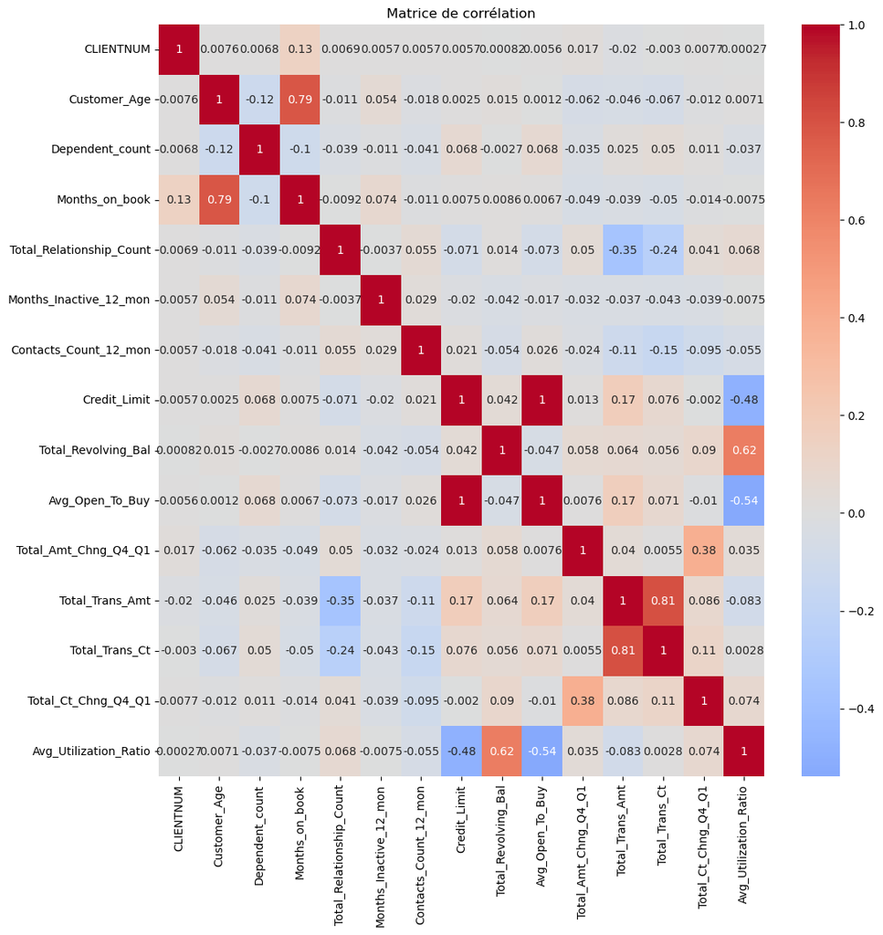

```python
corr = df.select_dtypes(include=['number']).corr()
plt.figure(figsize=(12, 12))
sns.heatmap(corr, annot=True, cmap='coolwarm', center=0)
plt.title("Matrice de corrélation")
plt.show()
```

#### Observations:

We have a total of 21 variables in our dataset and 10 127 observations.

We have 8 500 existing customers in the bank and 1 627 who have terminated their contracts.  
This represents a proportion of 83.93% of existing customers and 16.07% of customers who have terminated their contracts. We therefore have a bias in our database.

In terms of gender in the dataset, we have 53% women and 47% men.  
The distribution is more balanced than our variable of interest.

## 2 - Pre-Processing :

We start by removing the “CLIENTNUM” variable because this variable identifies the client, but we want a model that can be adapted to all clients, not just certain targeted clients.

```python
df = df.drop(columns=['CLIENTNUM'])
```

We now check whether we have any missing variables in our dataset, which will allow us to determine what we can do next to replace them (median, mean, PCA, ...)

```python
df.isna().sum()
```

```
Attrition_Flag              0
Customer_Age                0
Gender                      0
Dependent_count             0
Education_Level             0
Marital_Status              0
Income_Category             0
Card_Category               0
Months_on_book              0
Total_Relationship_Count    0
Months_Inactive_12_mon      0
Contacts_Count_12_mon       0
Credit_Limit                0
Total_Revolving_Bal         0
Avg_Open_To_Buy             0
Total_Amt_Chng_Q4_Q1        0
Total_Trans_Amt             0
Total_Trans_Ct              0
Total_Ct_Chng_Q4_Q1         0
Avg_Utilization_Ratio       0
dtype: int64
```

Although we do not have any missing variables in our dataset, we have observed that the variables “Education_Level,” “Marital_Status,” and “Income_Category” have ‘Unknown’ values. Since this information is still useful and we want as much information as possible for our model to be successful, we will process the variables with “Unknown” values. We also categorize the variables “Gender” and “Marital_Status” in order to have an even distribution.

```python
print("Observations with 'Uknown': {} sur {}".format((df[(df["Education_Level"] == "Unknown") |
   (df["Marital_Status"] == "Unknown") |
   (df["Income_Category"] == "Unknown")].shape[0]), df.shape[0]))
```

```
Observations with 'Uknown': 3046 sur 10127
```

We have 3 046 “Unknown” variables out of 10 127. Let's process them now so that we can use them in our model.

```python
# Variables à encoder
ordinal_cols = ["Education_Level", "Income_Category", "Card_Category"]
onehot_cols = ["Gender", "Marital_Status"]

# Définition des ordres logiques pour les variables ordinales
education_order = ["Unknown", "Uneducated", "High School", "College", "Graduate", "Post-Graduate", "Doctorate"]
income_order = ["Unknown", "Less than $40K", "$40K - $60K", "$60K - $80K", "$80K - $120K", "$120K +"]
card_order = ["Blue", "Silver", "Gold", "Platinum"]

# Création d'une copie pour ne pas modifier df
df_enc = df.copy()

# Encodage ordinal (les catégories sont converties en valeurs entières selon l'ordre défini)
ord_encoder = OrdinalEncoder(categories=[education_order, income_order, card_order])
df_enc[ordinal_cols] = ord_encoder.fit_transform(df_enc[ordinal_cols])

# Encodage one-hot (les catégories deviennent des colonnes binaires)
onehot_encoder = OneHotEncoder(handle_unknown="ignore", sparse=False)
onehot_encoded = pd.DataFrame(onehot_encoder.fit_transform(df_enc[onehot_cols]), columns=onehot_encoder.get_feature_names_out(onehot_cols), index=df_enc.index)


df_enc = pd.concat([df_enc.drop(columns=onehot_cols), onehot_encoded], axis=1)
df_enc.head()
```

|  | Attrition_Flag | Customer_Age | Dependent_count | Education_Level | Income_Category | Card_Category | Months_on_book | Total_Relationship_Count | Months_Inactive_12_mon | Contacts_Count_12_mon | ... | Total_Trans_Amt | Total_Trans_Ct | Total_Ct_Chng_Q4_Q1 | Avg_Utilization_Ratio | Gender_F | Gender_M | Marital_Status_Divorced | Marital_Status_Married | Marital_Status_Single | Marital_Status_Unknown |
| --- | --- | --- | --- | --- | --- | --- | --- | --- | --- | --- | --- | --- | --- | --- | --- | --- | --- | --- | --- | --- | --- |
| 0 | Existing Customer | 45 | 3 | 2.0 | 3.0 | 0.0 | 39 | 5 | 1 | 3 | ... | 1144 | 42 | 1.625 | 0.061 | 0.0 | 1.0 | 0.0 | 1.0 | 0.0 | 0.0 |
| 1 | Existing Customer | 49 | 5 | 4.0 | 1.0 | 0.0 | 44 | 6 | 1 | 2 | ... | 1291 | 33 | 3.714 | 0.105 | 1.0 | 0.0 | 0.0 | 0.0 | 1.0 | 0.0 |
| 2 | Existing Customer | 51 | 3 | 4.0 | 4.0 | 0.0 | 36 | 4 | 1 | 0 | ... | 1887 | 20 | 2.333 | 0.000 | 0.0 | 1.0 | 0.0 | 1.0 | 0.0 | 0.0 |
| 3 | Existing Customer | 40 | 4 | 2.0 | 1.0 | 0.0 | 34 | 3 | 4 | 1 | ... | 1171 | 20 | 2.333 | 0.760 | 1.0 | 0.0 | 0.0 | 0.0 | 0.0 | 1.0 |
| 4 | Existing Customer | 40 | 3 | 1.0 | 3.0 | 0.0 | 21 | 5 | 1 | 0 | ... | 816 | 28 | 2.500 | 0.000 | 0.0 | 1.0 | 0.0 | 1.0 | 0.0 | 0.0 |

5 rows × 24 columns

Having determined that we have no missing variables in our database, we can now move on to encoding our target variable. In order to determine the classes of our target variable, we identify existing customers with a flag of 0 and customers who have terminated their contracts with a flag of 1, as we are primarily seeking to predict whether customers will leave the bank.

```python
df_enc['Attrition_Flag'] = df_enc['Attrition_Flag'].map({'Existing Customer': 0, 'Attrited Customer': 1})
```

```python
df_enc.head()
```

|  | Attrition_Flag | Customer_Age | Dependent_count | Education_Level | Income_Category | Card_Category | Months_on_book | Total_Relationship_Count | Months_Inactive_12_mon | Contacts_Count_12_mon | ... | Total_Trans_Amt | Total_Trans_Ct | Total_Ct_Chng_Q4_Q1 | Avg_Utilization_Ratio | Gender_F | Gender_M | Marital_Status_Divorced | Marital_Status_Married | Marital_Status_Single | Marital_Status_Unknown |
| --- | --- | --- | --- | --- | --- | --- | --- | --- | --- | --- | --- | --- | --- | --- | --- | --- | --- | --- | --- | --- | --- |
| 0 | 0 | 45 | 3 | 2.0 | 3.0 | 0.0 | 39 | 5 | 1 | 3 | ... | 1144 | 42 | 1.625 | 0.061 | 0.0 | 1.0 | 0.0 | 1.0 | 0.0 | 0.0 |
| 1 | 0 | 49 | 5 | 4.0 | 1.0 | 0.0 | 44 | 6 | 1 | 2 | ... | 1291 | 33 | 3.714 | 0.105 | 1.0 | 0.0 | 0.0 | 0.0 | 1.0 | 0.0 |
| 2 | 0 | 51 | 3 | 4.0 | 4.0 | 0.0 | 36 | 4 | 1 | 0 | ... | 1887 | 20 | 2.333 | 0.000 | 0.0 | 1.0 | 0.0 | 1.0 | 0.0 | 0.0 |
| 3 | 0 | 40 | 4 | 2.0 | 1.0 | 0.0 | 34 | 3 | 4 | 1 | ... | 1171 | 20 | 2.333 | 0.760 | 1.0 | 0.0 | 0.0 | 0.0 | 0.0 | 1.0 |
| 4 | 0 | 40 | 3 | 1.0 | 3.0 | 0.0 | 21 | 5 | 1 | 0 | ... | 816 | 28 | 2.500 | 0.000 | 0.0 | 1.0 | 0.0 | 1.0 | 0.0 | 0.0 |

5 rows × 24 columns

In order to bring our variables to the same scale, we standardize them, i.e., we center and reduce them so that the mean of our data is equal to 0 and the variance is 1. We do this because without standardization, the model would give more weight to variables with higher values such as “Credit_Limit” or “Total_Trans_Amt.”

```python
X = df_enc.drop(columns=['Attrition_Flag'])
y = df_enc['Attrition_Flag']

scaler = StandardScaler()
X_scaled = scaler.fit_transform(X)
```

### 3 - Formalization of the problem :

Formalization of the problemWe have therefore prepared our data to perform a binary classification problem in order to determine whether or not customers will leave the bank. The objective is to predict the probability that a customer will leave the bank. To do this, we have the following variables:

| N° | Nom de la variable | Description de la variable |
| --- | --- | --- |
| 1️ | **CLIENTNUM** | Unique customer ID (number assigned by the bank). |
| 2 | **Attrition_Flag** | Customer status: • *Existing Customer* → current customer • *Attrited Customer* → customer who has left the bank. |
| 3 | **Customer_Age** | Age of the client. |
| 4 | **Gender** | Sex of the client : *M* (Men) ou *F* (Women). |
| 5 | **Dependent_count** | Number of dependents (children, unemployed spouse, etc.). |
| 6 | **Education_Level** | Client education level: *Uneducated*, *High School*, *Graduate*, *Doctorate*, etc. |
| 7 | **Marital_Status** | Client's marital status: *Single*, *Married*, *Divorced*, *Unknown*, etc. |
| 8 | **Income_Category** | Customer's annual income bracket: • *Less than $40K* • *$40K - $60K* • *$60K - $80K* • *$80K - $120K* • *$120K+* • *Unknown*. |
| 9 | **Card_Category** | Type of credit card owned: *Blue*, *Silver*, *Gold*, *Platinum*. |
| 10 | **Months_on_book** | Customer's length of time with the bank (in months). |
| 11 | **Total_Relationship_Count** | Total number of products held by the customer (e.g., checking account, savings account, card, loan, etc.). |
| 12 | **Months_Inactive_12_mon** | Number of months of inactivity over the last 12 months. |
| 13 | **Contacts_Count_12_mon** | Number of contacts (calls, emails, interactions) between the bank and the customer over the last 12 months. |
| 14 | **Credit_Limit** | Authorized credit limit for the customer's card. |
| 15 | **Total_Revolving_Bal** | Solde revolving total (partie du crédit utilisée mais non remboursée). |
| 16 | **Avg_Open_To_Buy** | Average amount available on the card (remaining credit = limit − balance used). |
| 17 | **Total_Amt_Chng_Q4_Q1** | Change in total transaction volume between the fourth and first quarters (Q4/Q1). → Measures growth or decline in financial activity. |
| 18 | **Total_Trans_Amt** | Total amount of transactions carried out over 12 months. |
| 19 | **Total_Trans_Ct** | Total number of transactions completed over 12 months. |
| 20 | **Total_Ct_Chng_Q4_Q1** | Change in the number of transactions between the fourth and first quarters (Q4/Q1). |
| 21 | **Avg_Utilization_Ratio** | Average credit utilization rate (ratio between balance and credit limit). Example: 0.2 = 20% of credit used. |

### Implementation of the Logistics Model:

We take care to stratify our training and test databases so that we have the same distribution in both databases and avoid a situation where all customers who have left the bank end up in the test database, for example, and the model does not know how to classify them. In order to be able to reproduce the model, we also set a seed at 42 and take a test database at 30%.

```python
X_train, X_test, y_train, y_test = train_test_split(X_scaled, y, test_size=0.3, random_state=42, stratify=y)

model = LogisticRegression(max_iter=1000)
model.fit(X_train, y_train)

y_pred = model.predict(X_test)

print(confusion_matrix(y_test, y_pred))
print(classification_report(y_test, y_pred))
```

```
[[2472   79]
 [ 226  262]]
              precision    recall  f1-score   support

           0       0.92      0.97      0.94      2551
           1       0.77      0.54      0.63       488

    accuracy                           0.90      3039
   macro avg       0.84      0.75      0.79      3039
weighted avg       0.89      0.90      0.89      3039
```

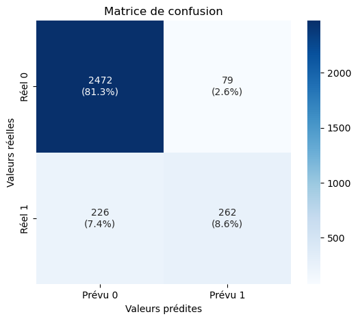

```python
cm = confusion_matrix(y_test, y_pred)
cm_sum = np.sum(cm)
cm_perc = cm / cm_sum * 100

annot = np.empty_like(cm).astype(str)

for i in range(cm.shape[0]):
    for j in range(cm.shape[1]):
        annot[i, j] = f"{cm[i, j]}\n({cm_perc[i, j]:.1f}%)"

plt.figure(figsize=(6, 5))
sns.heatmap(cm, annot=annot, fmt='', cmap='Blues',
            xticklabels=['Prévu 0', 'Prévu 1'],
            yticklabels=['Réel 0', 'Réel 1'])

plt.title('Matrice de confusion')
plt.xlabel('Valeurs prédites')
plt.ylabel('Valeurs réelles')
plt.show()
```

## Model Comparison

### Grid Search

```python
param_grid = {
    'n_estimators': [100, 150, 200],
    'max_depth': [None, 10, 15],
    'min_samples_split': [2,3,4,5],
}

grid_rf = GridSearchCV(RandomForestClassifier(random_state=42), param_grid, cv=5, scoring='accuracy', n_jobs=-1)
grid_rf.fit(X_train, y_train)

print(grid_rf.best_params_)
```

```
{'max_depth': None, 'min_samples_split': 5, 'n_estimators': 150}
```

Base on our grid_search, we can determine that our tree has no maximum depth, which allows the model to learn more complex patterns. We also observe that a node must have at least 5 samples to be split, which helps avoid overfitting. The forest contains 150 trees, which is a good compromise between performance and computation time.

Based on our results, we can say that we have found a good compromise between bias and variance.

### 1 - Random Forest

```python
best_rf = RandomForestClassifier(max_depth=None, min_samples_split=5, n_estimators=150, random_state=42)
best_rf.fit(X_train, y_train)
y_pred_rf = best_rf.predict(X_test)

print(f"Accuracy (Random Forest): {round(accuracy_score(y_test, y_pred_rf)*100,4)}%")
print(classification_report(y_test, y_pred_rf))
```

```
Accuracy (Random Forest): 95.6565%
              precision    recall  f1-score   support

           0       0.96      0.99      0.97      2551
           1       0.92      0.80      0.85       488

    accuracy                           0.96      3039
   macro avg       0.94      0.89      0.91      3039
weighted avg       0.96      0.96      0.96      3039
```

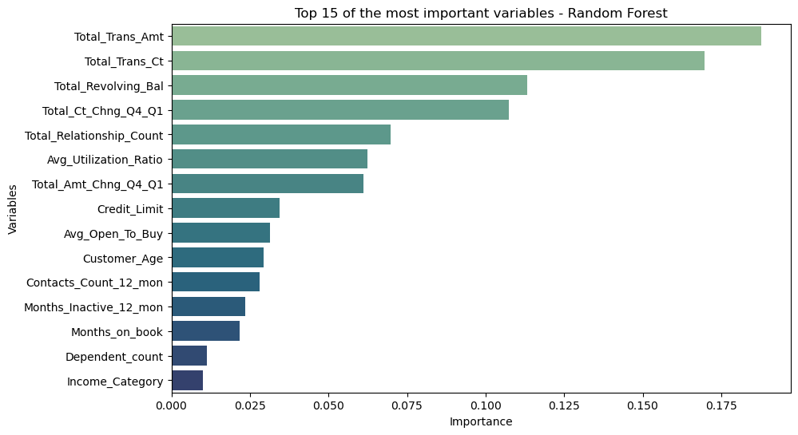

```python
importances_rf = best_rf.feature_importances_
indices = np.argsort(importances_rf)[::-1]
features = X.columns

plt.figure(figsize=(10,6))
sns.barplot(x=importances_rf[indices][:15], y=features[indices][:15], palette='crest')
plt.title("Top 15 of the most important variables - Random Forest")
plt.xlabel("Importance")
plt.ylabel("Variables")
plt.show()
```

The decision-making process of our Random Forest model is mainly determined by the following variables (for example the 5 firsts):

- Total_Trans_Amt, which is the most important variable representing the total amount of transactions made by the customer. Based on this variable, we can see that customers who spend less or significantly reduce their spending are the most likely to terminate their contracts.
- Total_Trans_Ct represents the number of transactions. The lower the number of transactions, the more likely the customer is to terminate their contract.
- Total_Revolving_Bal, which represents the account balance. A customer with a low or zero balance may be more likely to terminate their contract because they are less committed.
- Total_Ct_Chng_Q4_Q1, which determines the number of transactions between the first and fourth quarters. With a decreasing number of transactions, we can estimate that the commitment to the account is weaker, meaning that the customer is more likely to terminate their contract.
- Total_Relationship_Count represents the number of products held by the customer. The more products a customer has (premium card, insurance, accounts, loans, etc.), the less likely they are to leave.

### 2 - Bagging

```python
bagging = BaggingClassifier( base_estimator=DecisionTreeClassifier(), n_estimators=150, random_state=42)
bagging.fit(X_train, y_train)
y_pred_bag = bagging.predict(X_test)

print(f"Accuracy (Bagging): {round(accuracy_score(y_test, y_pred_bag) * 100,4)}%")
```

```
Accuracy (Bagging): 95.7223%
```

Bagging correctly predicts 95.7223% of the classification of our data.

### 3 - Voting

```python
log_reg = LogisticRegression(max_iter=1000)
svm = SVC(probability=True)
rf = best_rf

voting = VotingClassifier(estimators=[('lr', log_reg), ('svm', svm), ('rf', rf)], voting='soft')

voting.fit(X_train, y_train)
y_pred_vote = voting.predict(X_test)

print(f"Accuracy (Voting):, {round(accuracy_score(y_test, y_pred_vote)*100,4)}%")
```

```
Accuracy (Voting):, 92.6621%
```

### 4 - Stacking

```python
estimators = [ ('rf', rf), ('svm', svm)]

stacking = StackingClassifier( estimators=estimators, final_estimator=LogisticRegression(), passthrough=True)
stacking.fit(X_train, y_train)
y_pred_stack = stacking.predict(X_test)

print(f"Accuracy (Stacking):, {round(accuracy_score(y_test, y_pred_stack)*100,4)}%")
```

```
Accuracy (Stacking):, 96.1171%
```

Stacking correctly predicts 96.1171% of the classification of our data.

### Models comparison

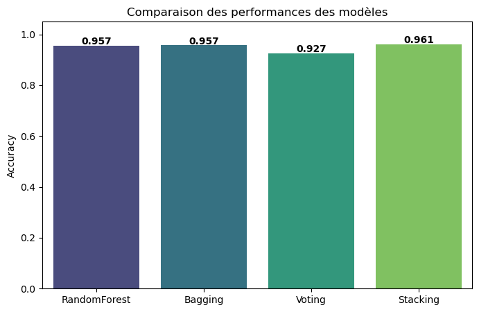

```python
import matplotlib.pyplot as plt
import seaborn as sns
from sklearn.metrics import accuracy_score

models = ['RandomForest', 'Bagging', 'Voting', 'Stacking']
scores = [
    accuracy_score(y_test, y_pred_rf),
    accuracy_score(y_test, y_pred_bag),
    accuracy_score(y_test, y_pred_vote),
    accuracy_score(y_test, y_pred_stack)
]

plt.figure(figsize=(8,5))
ax = sns.barplot(x=models, y=scores, palette='viridis')

plt.title("Comparaison des performances des modèles")
plt.ylabel("Accuracy")

# 🔹 Ajout des étiquettes de données
for i, v in enumerate(scores):
    ax.text(i, v + 0.005, f"{v:.3f}", ha='center', fontweight='bold')

plt.ylim(0, 1.05)  # pour laisser un peu d’espace au-dessus des barres
plt.show()
```

#### Roc Curve

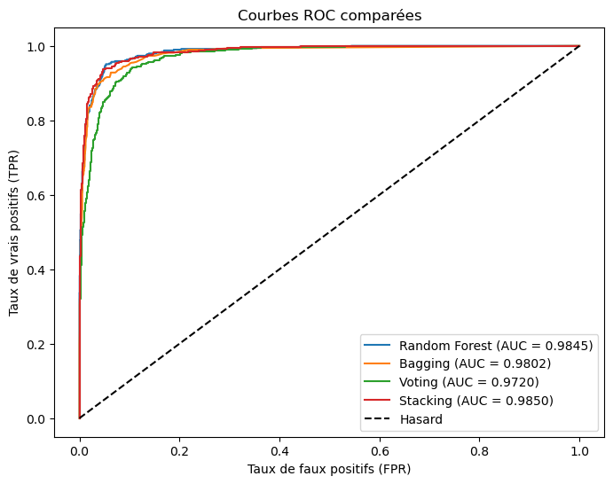

```python
plt.figure(figsize=(8,6))

models_pred_prob = {
    'Random Forest': best_rf.predict_proba(X_test)[:,1], 'Bagging': bagging.predict_proba(X_test)[:,1],
    'Voting': voting.predict_proba(X_test)[:,1], 'Stacking': stacking.predict_proba(X_test)[:,1]}

for name, y_prob in models_pred_prob.items():
    fpr, tpr, _ = roc_curve(y_test, y_prob)
    auc_score = auc(fpr, tpr)
    plt.plot(fpr, tpr, label=f"{name} (AUC = {auc_score:.4f})")

plt.plot([0,1], [0,1], 'k--', label='Hasard')
plt.title("Courbes ROC comparées")
plt.xlabel("Taux de faux positifs (FPR)")
plt.ylabel("Taux de vrais positifs (TPR)")
plt.legend()
plt.show()
```

The ROC curve shows us the ability to distinguish between true and false positives. The diagonal line represents chance in a random classification. According to the AUC, stacking has the best performance (0.9850), but the random forest model is not far behind (RF => 0.9845). The Voting curve is slightly lower, which also corresponds to its lower AUC.

#### Recall curve

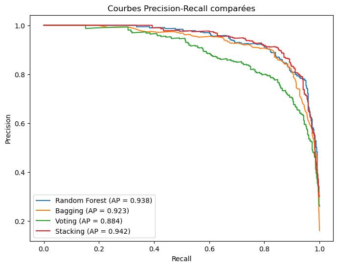

```python
plt.figure(figsize=(8,6))

for name, y_prob in models_pred_prob.items():
    precision, recall, _ = precision_recall_curve(y_test, y_prob)
    ap = average_precision_score(y_test, y_prob)
    plt.plot(recall, precision, label=f"{name} (AP = {ap:.3f})")

plt.title("Courbes Precision-Recall comparées")
plt.xlabel("Recall")
plt.ylabel("Precision")
plt.legend()
plt.show()
```

We also plot the Precision-Recall curve, as it allows us to better compare the performance of unbalanced classes.

All models remain effective, but stacking is the most effective. Random Forest is almost equivalent, which would provide a simpler alternative.

#### Confusion Matrix

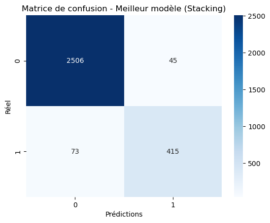

```python
best_model = stacking
y_pred_best = y_pred_stack

cm = confusion_matrix(y_test, y_pred_best)
sns.heatmap(cm, annot=True, fmt='d', cmap='Blues')
plt.title("Matrice de confusion - Meilleur modèle (Stacking)")
plt.xlabel("Prédictions")
plt.ylabel("Réel")
plt.show()
```

The stacking model has excellent overall performance with a good compromise between accuracy and recall. It makes few errors and misses few true positives. The results of the confusion matrix remain consistent with those of the ROC curve and the Precision-Recall curve.

The Stacking model is robust, accurate, and well calibrated.